# EDA HINTS DATA

```r
library(dplyr)
library(tidyr)
library(ggplot2)
library(lubridate)
library(gtsummary)
```

# Introduction

In the digital age, where information is readily available at our fingertips, understanding how people navigate and trust health information is critical. With countless sources such as healthcare professionals, government agencies, social media, and online forums, it is essential to explore what the United States population believes about the reliability and accessibility of health information. To better understand this phenomenon, data was gathered from an online forum called Reddit. The Reddit dataset comprises textual data that offers valuable insights into the information shared online about health, particularly topics related to cancer. Using NLP methods, we can explore the most common topics and also the sentiment toward these topics. In addition to the textual data, we will also use the Health Information National Trends Survey (HINTS), which is administered by National Cancer Institute. In this survey, people were asked directly about what they think about health information. Using both the Reddit data and HINTS, we seek to understand trust, frustrations, and overall sentiment about healthcare and more specifically, cancer information.

The Health Information National Trends Survey (HINTS) is a national survey administered by the National Cancer Institute. The survey is completed by civilians in the United States. The information gathered from the survey seeks to gain an understanding of what people think about the accessibility of health information and the perceptions of what people think about the health information. The HINTS survey includes 527 questions. To focus on sentiment toward healthcare and cancer, we selected the questions in Table 1. In Table 1, participants were asked various questions about where they access health information, do they trust the provided health information, and if they feel frustrated about the information.

**Table 1**

| **Variable** | **Description** |
| --- | --- |
| SeekCancerInfo | Have you ever looked for information about cancer from any source? |
| CancerFrustrated | Based on the results of your most recent search for information about cancer, how much do you agree or disagree: You felt frustrated during your search for the information. |
| CancerTrustDoctor | In general, how much would you trust information about cancer from a doctor? |
| CancerTrustFamily | In general, how much would you trust information about cancer from family or friends? |
| CancerTrustGov | In general, how much would you trust information about cancer from government health agencies? |
| CancerTrustCharities | In general, how much would you trust information about cancer from charitable organizations? |
| CancerTrustReligiousOrgs | In general, how much would you trust information about cancer from religious organizations and leaders? |
| CancerTrustScientists | In general, how much would you trust information about cancer from scientists? |
| Electronic2_HealthInfo | In the past 12 months have you used the Internet to look for health or medical information? |
| MisleadingHealthInfo | How much of the health information that you see on social media do you think is false or misleading? |
| TrustHCSystem | How much do you trust the health care system (for example, hospitals, pharmacies, and other organizations involved in health care)? |

```r
load('hints6_public.rda')
hints <- as.data.frame(public)

#print(colnames(hints))

columns <- c("HHID", "updatedate", "SeekCancerInfo", "CancerFrustrated", "CancerTrustDoctor", "CancerTrustFamily", "CancerTrustGov", "CancerTrustCharities", "CancerTrustReligiousOrgs", "CancerTrustScientists", "Electronic2_HealthInfo", "MisleadingHealthInfo", "TrustHCSystem")

hints_select <- hints %>% select(all_of(columns))
#hints_select$updatedate <- hints_select$updatedate / 1000
#hints_select$updatedate <- as_datetime(hints_select$updatedate)

head(hints_select)
```

```
      HHID  updatedate SeekCancerInfo                        CancerFrustrated
1 21000006 13870396800             No Inapplicable, coded 2 in SeekCancerInfo
2 21000009 13874630400             No Inapplicable, coded 2 in SeekCancerInfo
3 21000020 13873680000            Yes                       Somewhat disagree
4 21000022 13867891200             No Inapplicable, coded 2 in SeekCancerInfo
5 21000039 13866336000             No Inapplicable, coded 2 in SeekCancerInfo
6 21000043 13866595200             No Inapplicable, coded 2 in SeekCancerInfo
  CancerTrustDoctor              CancerTrustFamily
1             A lot Missing data (Not Ascertained)
2             A lot                           Some
3             A lot                           Some
4             A lot Missing data (Not Ascertained)
5              Some                           Some
6             A lot                           Some
                  CancerTrustGov           CancerTrustCharities
```

[output cut: 27 more lines]

# Survey Responses

In the bar graphs, a first look at the data provides an general overview of the responses to the questions. These plots show how much participants agree or disagree to each question. For example, many participants can trust doctors a lot and less than family members.

```r
plot_data <- hints_select %>%
  select(-HHID, -updatedate) %>%  # Exclude the first two columns
  pivot_longer(everything(), names_to = "Variable", values_to = "Value") %>%
  count(Variable, Value)

print(unique(plot_data$Value))
```

```
 [1] Missing data (Not Ascertained)
 [2] Missing data (Filter Missing)
 [3] Multiple responses selected in error
 [4] Question answered in error (Commission Error)
 [5] Inapplicable, coded 2 in SeekCancerInfo
 [6] Strongly agree
 [7] Somewhat agree
 [8] Somewhat disagree
 [9] Strongly disagree
[10] A lot
[11] Some
[12] A little
[13] Not at all
[14] Yes
[15] No
[16] Inapplicable, coded 2 in UseInternet
[17] Missing data (Web partial - Question Never Seen)
[18] None
[19] I do not use social media
[20] Very
[21] Somewhat
21 Levels: Missing data (Not Ascertained) Yes ... Somewhat
```

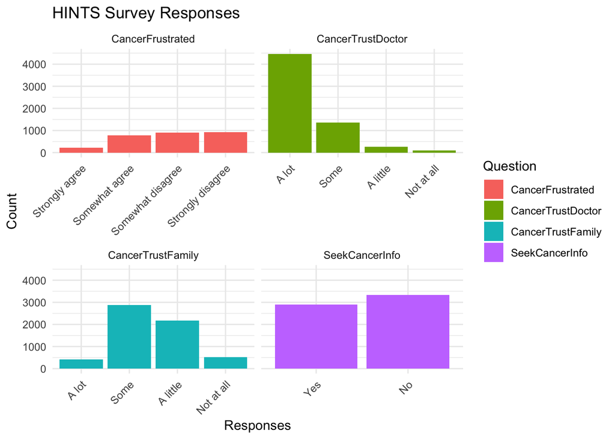

```r
values <- c("Strongly agree", "Somewhat agree", "Somewhat disagree", "Strongly disagree", "A lot", "Some",
            "A little", "Not at all", "Yes", "No", "None", "I do not use social media", "Very", "Somewhat")

plot_data_filtered <- plot_data %>% filter(Value %in% values)
plot_data_filtered$Value <- factor(plot_data_filtered$Value, levels = sort(unique(plot_data_filtered$Value)))

columns_1 <- c("SeekCancerInfo", "CancerFrustrated", "CancerTrustDoctor", "CancerTrustFamily")
plot_data_filtered_1 <- plot_data_filtered %>% filter(Variable %in% columns_1)
columns_2 <- c("CancerTrustGov", "CancerTrustCharities", "CancerTrustReligiousOrgs", "CancerTrustScientists")
plot_data_filtered_2 <- plot_data_filtered %>% filter(Variable %in% columns_2)
columns_3 <- c("Electronic2_HealthInfo", "MisleadingHealthInfo", "TrustHCSystem")
plot_data_filtered_3 <- plot_data_filtered %>% filter(Variable %in% columns_3)

p <- ggplot(plot_data_filtered_1, aes(x = Value, y = n, fill = Variable)) +
  geom_bar(stat = "identity") +
  facet_wrap(~ Variable, scales = "free_x") +  # Separate plots for each column
  theme_minimal() +
  labs(
    title = "HINTS Survey Responses",
    x = "Responses",
    y = "Count",
    fill = "Question"
  ) +
  theme(axis.text.x = element_text(angle = 45, hjust = 1))

p
```

```r
png("plots/HINTS_plot1.png", width = 800, height = 600)
print(p)
dev.off()
```

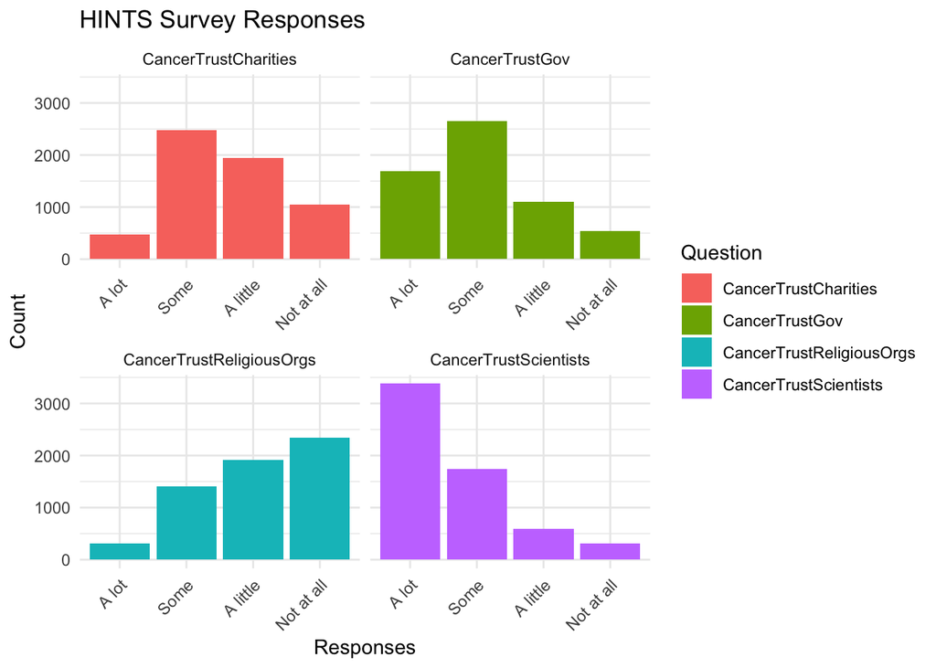

```r
p <- ggplot(plot_data_filtered_2, aes(x = Value, y = n, fill = Variable)) +
  geom_bar(stat = "identity") +
  facet_wrap(~ Variable, scales = "free_x") +
  theme_minimal() +
  labs(
    title = "HINTS Survey Responses",
    x = "Responses",
    y = "Count",
    fill = "Question"
  ) +
  theme(axis.text.x = element_text(angle = 45, hjust = 1))

p
```

```r
png("plots/HINTS_plot2.png", width = 800, height = 600)
print(p)
dev.off()
```

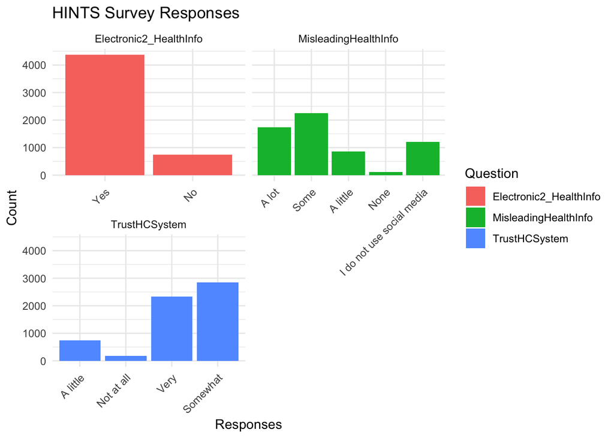

```r
p <- ggplot(plot_data_filtered_3, aes(x = Value, y = n, fill = Variable)) +
  geom_bar(stat = "identity") +
  facet_wrap(~ Variable, scales = "free_x", nrow=2) +
  theme_minimal() +
  labs(
    title = "HINTS Survey Responses",
    x = "Responses",
    y = "Count",
    fill = "Question"
  ) +
  theme(axis.text.x = element_text(angle = 45, hjust = 1))

p
```

```r
png("plots/HINTS_plot3.png", width = 800, height = 600)
print(p)
dev.off()
```

# Summary Statistics of the Responses

The responses of the questions can be coded into a scale from 0:3. For example, “Not at all” is coded as 0, “A little” is coded as 1, “Some” is coded as 2, and “A lot” is coded as 3. After coding these responses, the mean, median, and mode is calculated to highlight overall trends in the data.

```r
print(unique(hints_select$MisleadingHealthInfo))
```

```
[1] I do not use social media
[2] Some
[3] A lot
[4] A little
[5] None
[6] Missing data (Not Ascertained)
[7] Missing data (Web partial - Question Never Seen)
7 Levels: Missing data (Not Ascertained) ...
```

```r
print(colnames(hints_select))
```

```
 [1] "HHID"                     "updatedate"
 [3] "SeekCancerInfo"           "CancerFrustrated"
 [5] "CancerTrustDoctor"        "CancerTrustFamily"
 [7] "CancerTrustGov"           "CancerTrustCharities"
 [9] "CancerTrustReligiousOrgs" "CancerTrustScientists"
[11] "Electronic2_HealthInfo"   "MisleadingHealthInfo"
[13] "TrustHCSystem"
```

```r
hints_select_coded <- hints_select %>%
  mutate(CancerFrustrated = as.numeric(case_when(
    CancerFrustrated == "Strongly disagree" ~ "0",
    CancerFrustrated == "Somewhat disagree" ~ "1",
    CancerFrustrated == "Somewhat agree" ~ "2",
    CancerFrustrated == "Strongly agree" ~ "3",
    TRUE ~  NA
  )))

hints_select_coded <- hints_select_coded %>%
  mutate(CancerTrustDoctor = as.numeric(case_when(
    CancerTrustDoctor == "Not at all" ~ "0",
    CancerTrustDoctor == "A little" ~ "1",
    CancerTrustDoctor == "Some" ~ "2",
    CancerTrustDoctor == "A lot" ~ "3",
    TRUE ~  NA
  )))

hints_select_coded <- hints_select_coded %>%
  mutate(CancerTrustFamily = as.numeric(case_when(
    CancerTrustFamily == "None" ~ "0",
    CancerTrustFamily == "A little" ~ "1",
    CancerTrustFamily == "Some" ~ "2",
    CancerTrustFamily == "A lot" ~ "3",
    TRUE ~ NA
  )))

hints_select_coded <- hints_select_coded %>%
  mutate(SeekCancerInfo = as.numeric(case_when(
    SeekCancerInfo == "Yes" ~ "1",
    SeekCancerInfo == "No" ~ "0",
    TRUE ~ NA
  )))

hints_select_coded <- hints_select_coded %>%
  mutate(CancerTrustCharities = as.numeric(case_when(
    CancerTrustCharities == "Not at all" ~ "0",
    CancerTrustCharities == "A little" ~ "1",
    CancerTrustCharities == "Some" ~ "2",
    CancerTrustCharities == "A lot" ~ "3",
    TRUE ~ NA
  )))

hints_select_coded <- hints_select_coded %>%
  mutate(CancerTrustGov = as.numeric(case_when(
    CancerTrustGov == "Not at all" ~ "0",
    CancerTrustGov == "A little" ~ "1",
    CancerTrustGov == "Some" ~ "2",
    CancerTrustGov == "A lot" ~ "3",
    TRUE ~ NA
  )))

hints_select_coded <- hints_select_coded %>%
  mutate(CancerTrustReligiousOrgs = as.numeric(case_when(
    CancerTrustReligiousOrgs == "Not at all" ~ "0",
    CancerTrustReligiousOrgs == "A little" ~ "1",
    CancerTrustReligiousOrgs == "Some" ~ "2",
    CancerTrustReligiousOrgs == "A lot" ~ "3",
    TRUE ~ NA
  )))

hints_select_coded <- hints_select_coded %>%
  mutate(CancerTrustScientists = as.numeric(case_when(
    CancerTrustScientists == "Not at all" ~ "0",
    CancerTrustScientists == "A little" ~ "1",
    CancerTrustScientists == "Some" ~ "2",
    CancerTrustScientists == "A lot" ~ "3",
    TRUE ~ NA
  )))

hints_select_coded <- hints_select_coded %>%
  mutate(Electronic2_HealthInfo = as.numeric(case_when(
    Electronic2_HealthInfo == "Yes" ~ "1",
    Electronic2_HealthInfo == "No" ~ "0",
    TRUE ~ NA
  )))

hints_select_coded <- hints_select_coded %>%
  mutate(MisleadingHealthInfo = as.numeric(case_when(
    MisleadingHealthInfo == "None" ~ "0",
    MisleadingHealthInfo == "I do not use social media" ~ "0",
    MisleadingHealthInfo == "A little" ~ "1",
    MisleadingHealthInfo == "Some" ~ "2",
    MisleadingHealthInfo == "A lot" ~ "3",
    TRUE ~ NA
  )))

hints_select_coded <- hints_select_coded %>%
  mutate(TrustHCSystem = as.numeric(case_when(
    TrustHCSystem == "Not at all" ~ "0",
    TrustHCSystem == "A little" ~ "1",
    TrustHCSystem == "Somewhat" ~ "2",
    TrustHCSystem == "Very" ~ "3",
    TRUE ~ NA
  )))


print(head(hints_select_coded))
```

```
      HHID  updatedate SeekCancerInfo CancerFrustrated CancerTrustDoctor
1 21000006 13870396800              0               NA                 3
2 21000009 13874630400              0               NA                 3
3 21000020 13873680000              1                1                 3
4 21000022 13867891200              0               NA                 3
5 21000039 13866336000              0               NA                 2
6 21000043 13866595200              0               NA                 3
  CancerTrustFamily CancerTrustGov CancerTrustCharities
1                NA             NA                   NA
2                 2              3                    2
3                 2              2                    1
4                NA             NA                   NA
5                 2              2                    0
6                 2              2                    3
  CancerTrustReligiousOrgs CancerTrustScientists Electronic2_HealthInfo
1                       NA                    NA                     NA
2                        2                     3                      1
3                        0                     3                      1
4                       NA                    NA                     NA
5                        0                     2                      1
6                        1                     3                      1
  MisleadingHealthInfo TrustHCSystem
1                    0             3
2                    0             3
3                    2             2
4                    0             2
5                    3             2
6                    3             1
```

In the summary table below, the mean for trusting a doctor is higher than trusting the government. Given this information, we will also look at the Reddit dataset to see the level of trust users have when they mention the government in their comments versus doctors. In addition, the people who felt frustrated about the information they received about cancer is approximately 1.105. In the Reddit dataset, we also look for an equivalent using textual data by looking at positive/negative and emotion sentiment analysis on comments that include the word “cancer”.

```r
print(summary(hints_select_coded))
```

```
     HHID             updatedate        SeekCancerInfo   CancerFrustrated
 Length:6252        Min.   :1.387e+10   Min.   :0.0000   Min.   :0.000
 Class :character   1st Qu.:1.387e+10   1st Qu.:0.0000   1st Qu.:0.000
 Mode  :character   Median :1.387e+10   Median :0.0000   Median :1.000
                    Mean   :1.387e+10   Mean   :0.4654   Mean   :1.105
                    3rd Qu.:1.387e+10   3rd Qu.:1.0000   3rd Qu.:2.000
                    Max.   :1.389e+10   Max.   :1.0000   Max.   :3.000
                                        NA's   :17       NA's   :3420
 CancerTrustDoctor CancerTrustFamily CancerTrustGov CancerTrustCharities
 Min.   :0.000     Min.   :1.000     Min.   :0.00   Min.   :0.000
 1st Qu.:2.000     1st Qu.:1.000     1st Qu.:1.00   1st Qu.:1.000
 Median :3.000     Median :2.000     Median :2.00   Median :1.000
 Mean   :2.656     Mean   :1.678     Mean   :1.92   Mean   :1.403
 3rd Qu.:3.000     3rd Qu.:2.000     3rd Qu.:3.00   3rd Qu.:2.000
 Max.   :3.000     Max.   :3.000     Max.   :3.00   Max.   :3.000
 NA's   :94        NA's   :783       NA's   :273    NA's   :308
 CancerTrustReligiousOrgs CancerTrustScientists Electronic2_HealthInfo
 Min.   :0.0000           Min.   :0.000         Min.   :0.0000
 1st Qu.:0.0000           1st Qu.:2.000         1st Qu.:1.0000
 Median :1.0000           Median :3.000         Median :1.0000
 Mean   :0.9484           Mean   :2.357         Mean   :0.8534
 3rd Qu.:2.0000           3rd Qu.:3.000         3rd Qu.:1.0000
 Max.   :3.0000           Max.   :3.000         Max.   :1.0000
 NA's   :280              NA's   :218           NA's   :1130
 MisleadingHealthInfo TrustHCSystem
 Min.   :0.000        Min.   :0.0
 1st Qu.:1.000        1st Qu.:2.0
 Median :2.000        Median :2.0
 Mean   :1.716        Mean   :2.2
 3rd Qu.:3.000        3rd Qu.:3.0
 Max.   :3.000        Max.   :3.0
 NA's   :82           NA's   :134
```

```r
hints_select_coded_clean <- drop_na(hints_select_coded)

table1 <- hints_select_coded_clean %>%
  select(-HHID, -updatedate) %>%
  tbl_summary(
    statistic = all_continuous() ~ "{mean} ± {sd}",
  )

table1
```

| **Characteristic** | **N = 2,315** <sup>1</sup> |
| --- | --- |
| SeekCancerInfo |  |
| 1 | 2,315 (100%) |
| CancerFrustrated |  |
| 0 | 759 (33%) |
| 1 | 780 (34%) |
| 2 | 624 (27%) |
| 3 | 152 (6.6%) |
| CancerTrustDoctor |  |
| 0 | 11 (0.5%) |
| 1 | 72 (3.1%) |
| 2 | 441 (19%) |
| 3 | 1,791 (77%) |
| CancerTrustFamily |  |
| 1 | 970 (42%) |
| 2 | 1,225 (53%) |
| 3 | 120 (5.2%) |
| CancerTrustGov |  |
| 0 | 133 (5.7%) |
| 1 | 357 (15%) |
| 2 | 1,065 (46%) |
| 3 | 760 (33%) |
| CancerTrustCharities |  |
| 0 | 251 (11%) |
| 1 | 798 (34%) |
| 2 | 1,086 (47%) |
| 3 | 180 (7.8%) |
| CancerTrustReligiousOrgs |  |
| 0 | 907 (39%) |
| 1 | 832 (36%) |
| 2 | 494 (21%) |
| 3 | 82 (3.5%) |
| CancerTrustScientists |  |
| 0 | 41 (1.8%) |
| 1 | 165 (7.1%) |
| 2 | 608 (26%) |
| 3 | 1,501 (65%) |
| Electronic2_HealthInfo | 2,203 (95%) |
| MisleadingHealthInfo |  |
| 0 | 287 (12%) |
| 1 | 287 (12%) |
| 2 | 959 (41%) |
| 3 | 782 (34%) |
| TrustHCSystem |  |
| 0 | 60 (2.6%) |
| 1 | 231 (10.0%) |
| 2 | 1,109 (48%) |
| 3 | 915 (40%) |

<sup>1</sup> n (%)

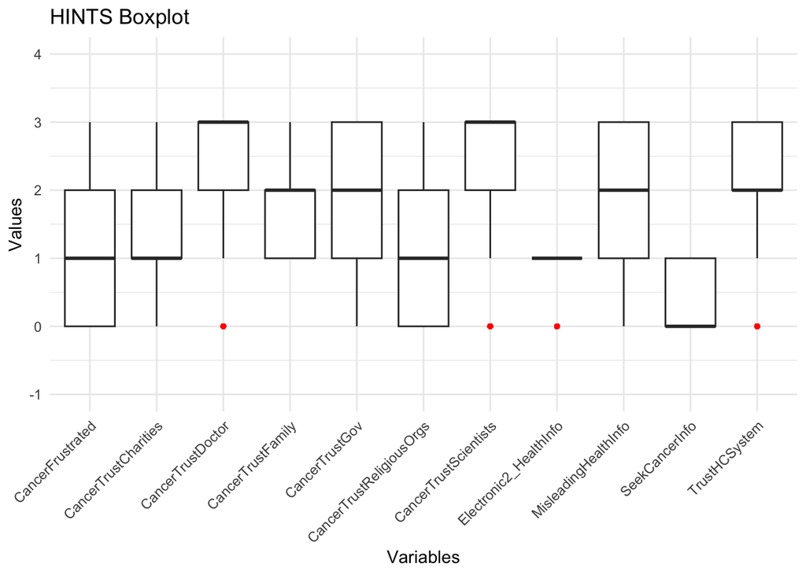

```r
boxplot_data <- hints_select_coded %>%
  select(-HHID, -updatedate)


boxplot_data_long <- boxplot_data %>%
  pivot_longer(cols = everything(), names_to = "Variable", values_to = "Value")


ggplot(boxplot_data_long, aes(x = Variable, y = Value)) +
  geom_boxplot(outlier.colour = "red", outlier.size = 1) +
  theme_minimal() +
  theme(axis.text.x = element_text(angle = 45, hjust = 1)) +
  labs(
    title = "HINTS Boxplot",
    x = "Variables",
    y = "Values"
  ) + coord_cartesian(ylim = c(-1, 4))
```

# Relationship between different survey questions.

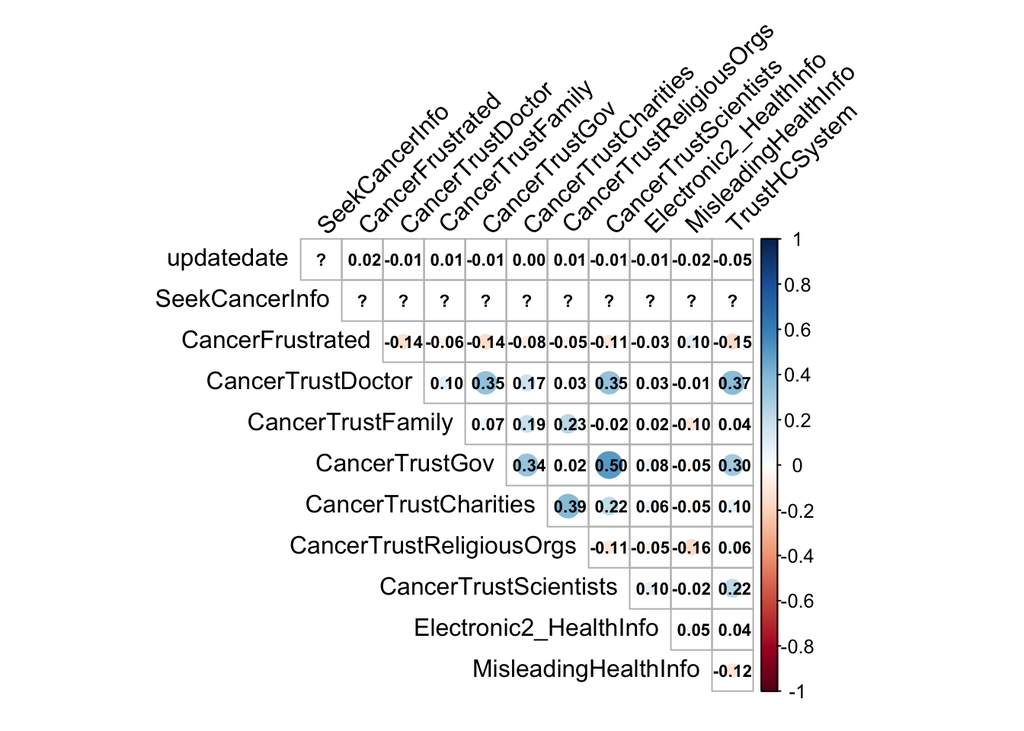

```r
library(corrplot)
cor_matrix <- drop_na(hints_select_coded)

# correlation matrix
cor_matrix <- cor(cor_matrix[, sapply(cor_matrix, is.numeric)], use = "complete.obs")
# correlation plot
corrplot(cor_matrix, method = "circle", type = "upper", tl.col = "black", tl.srt = 45,
         addCoef.col = "black", number.cex = 0.7, diag = FALSE)
```

# Further Directions and Conclusion

The HINTS dataset provides insight into the perceptions of healthcare and cancer information. The trends in this dataset will be repeated in the Reddit dataset. Using the Reddit dataset, we will explore sentiments, such as positive/negative, frustrations, and trust. We will also look at word frequency count to review, which topics Reddit users commonly comment about.